# Marginal/Interaction scans: centers vs. weighted linear models

Andrey Ziyatdinov

2017-06-13

# 1 Matrices

## 1.1 GARM

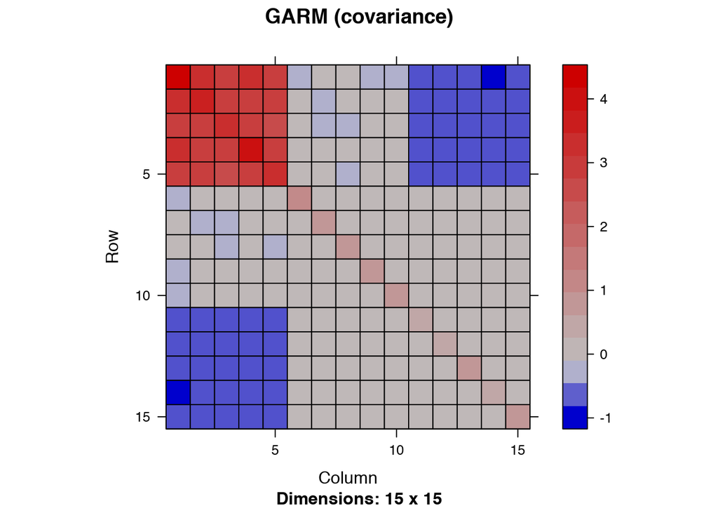

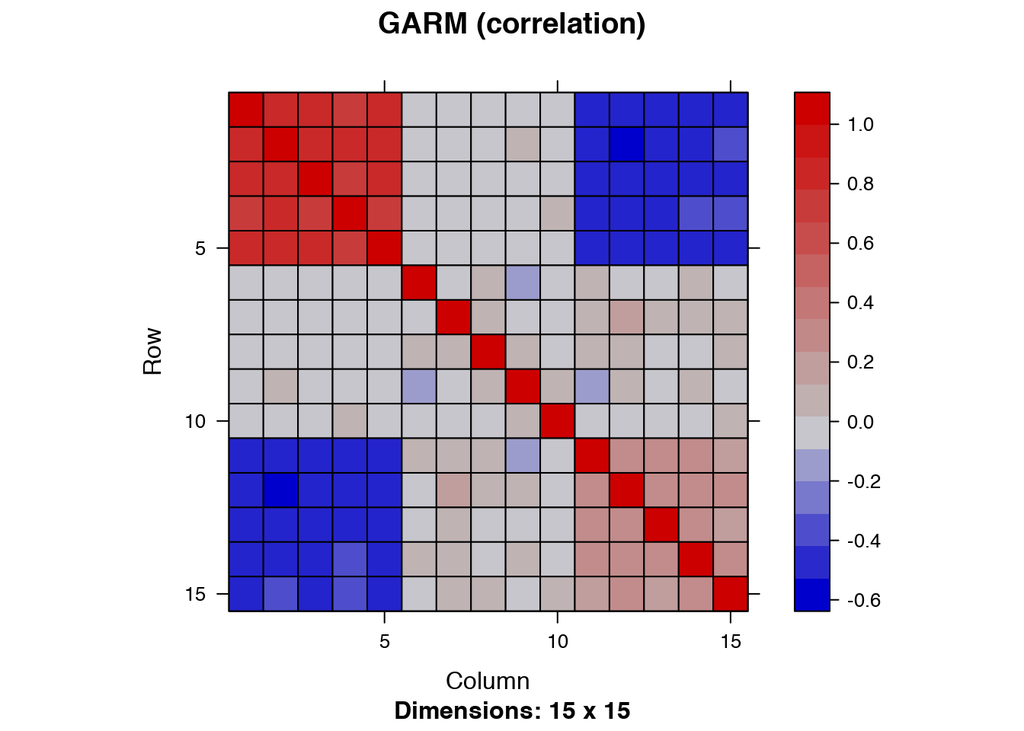

## 1.2 ARM

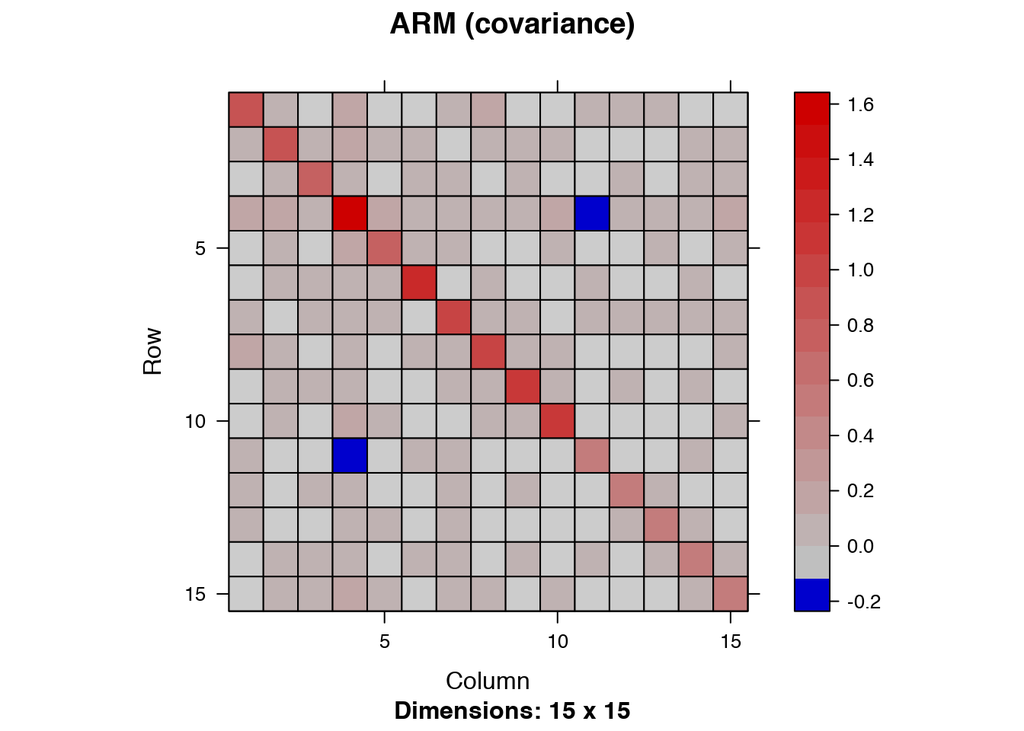

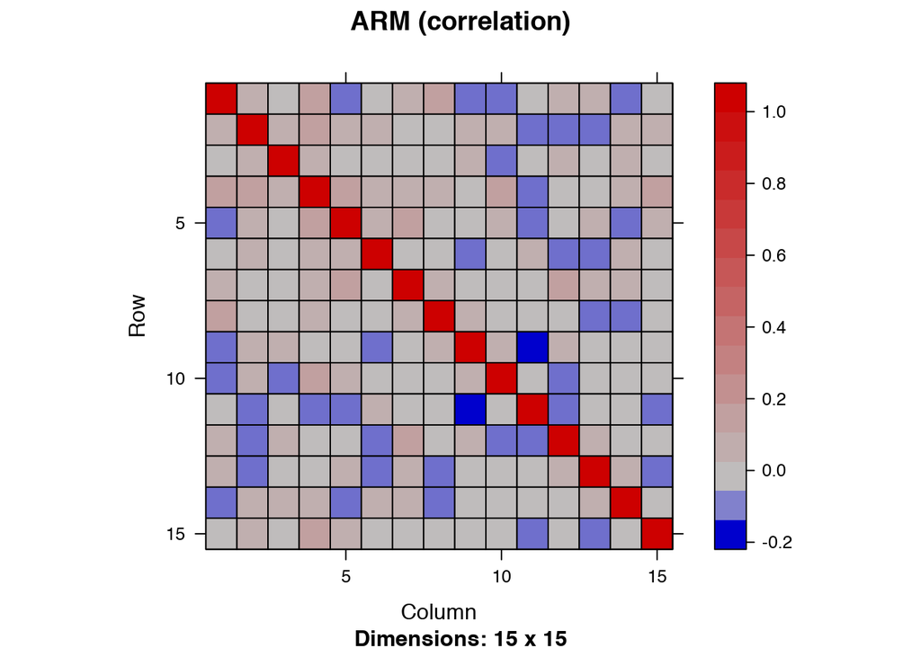

## 1.3 ARM_D

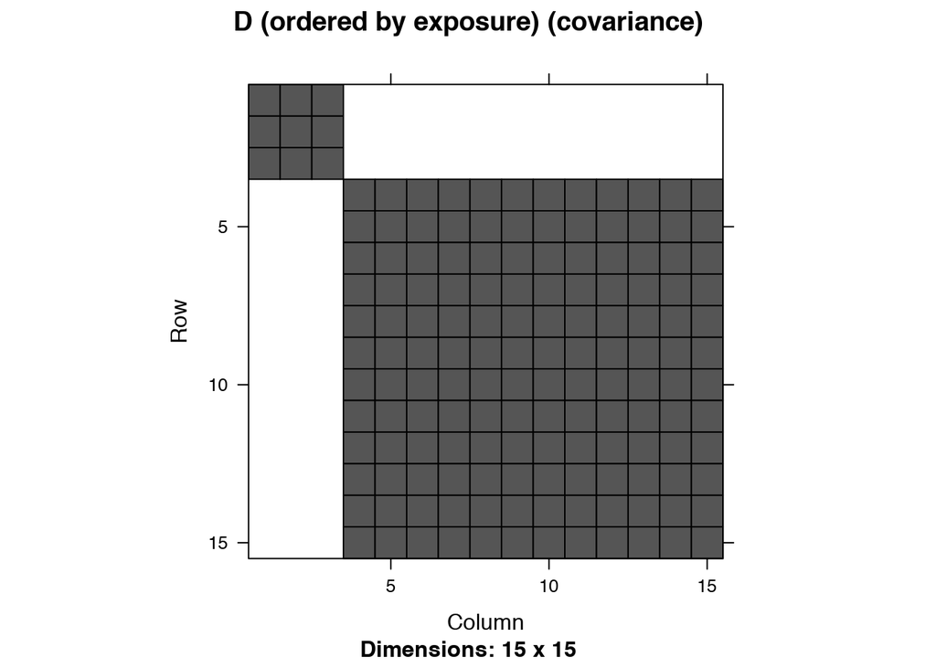

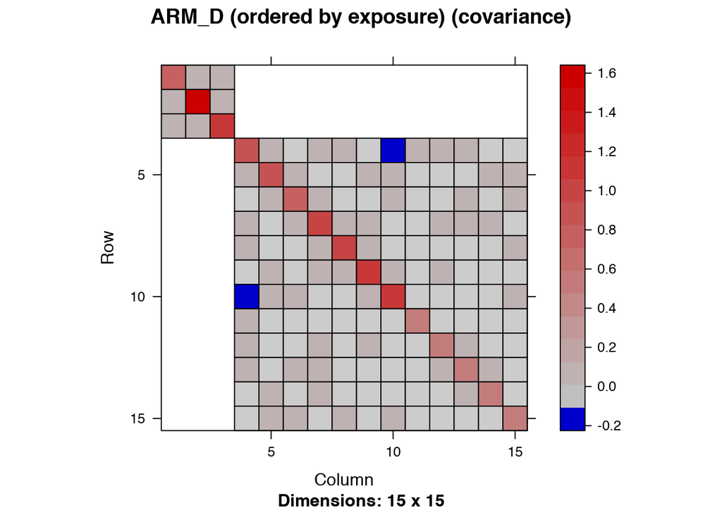

# 2 Models

## 2.1 Covariates

Covariates used as fixed effects:

| trait | cov |
| --- | --- |
| FEV1_FVC_utah | Age_Enroll, Age_Enroll2, gender, SmokCigNow, ATS_PackYears, acs_global |
| FEV1pp_utah | Age_Enroll, gender, SmokCigNow, ATS_PackYears, acs_global |
| FEV1_utah | Age_Enroll, Age_Enroll2, gender, Height_CM, SmokCigNow, ATS_PackYears, acs_global |
| FVCpp_utah | Age_Enroll, gender, SmokCigNow, ATS_PackYears, acs_global |
| FVC_utah | Age_Enroll, Age_Enroll2, gender, Height_CM, SmokCigNow, ATS_PackYears, acs_global |
| log_pctEmph_Slicer | Age_Enroll, gender, SmokCigNow, ATS_PackYears, acs_global |
| TLCpp_race_adjusted | Age_Enroll, gender, SmokCigNow, ATS_PackYears, acs_global |
| finalGold_bin | Age_Enroll, gender, SmokCigNow, ATS_PackYears, acs_global |

## 2.2 Grouping variables

Grouping variables used as random effects:

| trait | gr |
| --- | --- |
| FEV1_FVC_utah | ccenter |
| FEV1pp_utah | ccenter |
| FEV1_utah | ccenter |
| FVCpp_utah | ccenter |
| FVC_utah | ccenter |
| log_pctEmph_Slicer | ccenter, scanner_gr |
| TLCpp_race_adjusted | ccenter |
| finalGold_bin | ccenter |

## 2.3 Explained variance (marginal)

### 2.3.1 Estimated by lme4qtl

| trait | var_prop_sid | var_prop_ccenter | var_prop_Residual |
| --- | --- | --- | --- |
| FEV1_FVC_utah | 0.01124 | 0.05235 | 0.9364 |
| FEV1pp_utah | 0.01092 | 0.05803 | 0.9311 |
| FEV1_utah | 0.01045 | 0.04712 | 0.9424 |
| FVCpp_utah | 0.005956 | 0.03475 | 0.9593 |

### 2.3.2 Estimated by sommer (NR method)

| trait | var_prop_sid | var_prop_ccenter | var_prop_Residual |
| --- | --- | --- | --- |
| FEV1_FVC_utah | 0.01124 | 0.05236 | 0.9364 |
| FEV1pp_utah | 0.01092 | 0.05803 | 0.9311 |
| FEV1_utah | 0.01045 | 0.04712 | 0.9424 |
| FVCpp_utah | 0.005958 | 0.03475 | 0.9593 |
| FVC_utah | 0.007153 | 0.03328 | 0.9596 |
| log_pctEmph_Slicer | 0.01168 | 0.03615 | 0.7635 |
| TLCpp_race_adjusted | 0.01704 | 0.03314 | 0.9498 |

## 2.4 Explained variance (interaction)

### 2.4.1 Estimated by sommer (NR method)

| trait | var_prop_sid | var_prop_esid | var_prop_ccenter | var_prop_Residual |
| --- | --- | --- | --- | --- |
| FEV1_FVC_utah | 0.005274 | 0.01498 | 0.05345 | 0.9263 |
| FEV1pp_utah | 0 | 0.03627 | 0.05624 | 0.9075 |
| FEV1_utah | 0 | 0.0289 | 0.04601 | 0.9251 |
| FVCpp_utah | 0 | 0.03691 | 0.03286 | 0.9302 |
| FVC_utah | 0 | 0.03031 | 0.03179 | 0.9379 |
| log_pctEmph_Slicer | 0.00869 | 0.006287 | 0.03707 | 0.7593 |
| TLCpp_race_adjusted | 0.01397 | 0.005357 | 0.03311 | 0.9476 |

### 2.4.2 Estimated by sommer (NR method, unconstrained)

| trait | var_prop_sid | var_prop_esid | var_prop_ccenter | var_prop_Residual |
| --- | --- | --- | --- | --- |
| FEV1_FVC_utah | 0.005193 | 0.01652 | 0.05311 | 0.9252 |
| FEV1pp_utah | -0.007522 | 0.03297 | 0.05757 | 0.917 |
| FEV1_utah | -0.006444 | 0.02748 | 0.04674 | 0.9322 |
| FVCpp_utah | -0.01582 | 0.03425 | 0.03425 | 0.9473 |
| FVC_utah | -0.01331 | 0.03022 | 0.03271 | 0.9504 |
| log_pctEmph_Slicer | 0.00869 | 0.006303 | 0.03707 | 0.7593 |
| TLCpp_race_adjusted | 0.01398 | 0.005378 | 0.0331 | 0.9475 |

# 3 Marginal scans

We compare two scans:

1. `centers`: we included the only random effect `(1|ccenter)`
2. `centers + arm`: we included two random effects `(1|ccenter)` and `(1|sid)`
   - `(1|sid)` has the var-covar matrix equal to ARM (not GARM).

Onservations

- The first scan `centers` produces inflated test statistics.
  - the inflation is less for traits with the lower `h2_arm`
    - `FVCpp_utah` (`h2_arm` 0.006, lambda 1.03)
    - `FVC_utah` (`h2_arm` 0.007, lambda 1.06)
- The second scan `centers + arm` is able to produce good qq-plots (the inflation factor is between 0.94 and 1.03).

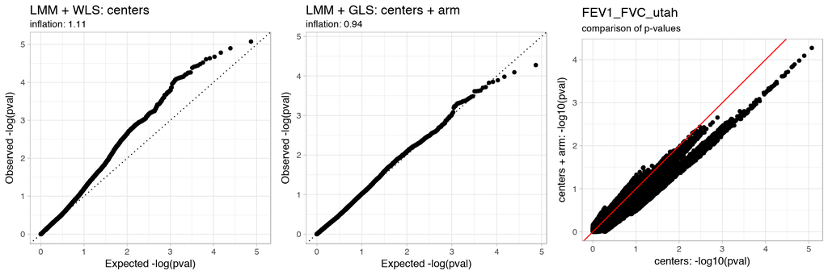

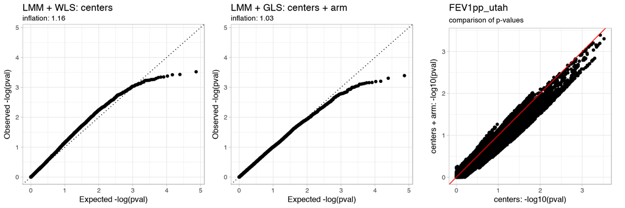

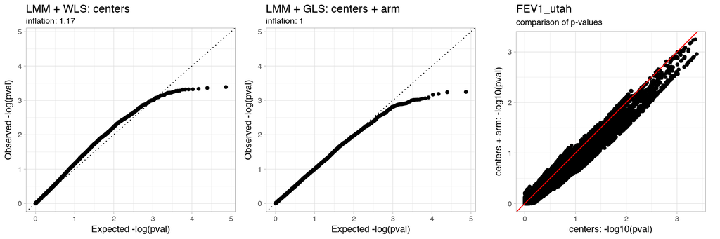

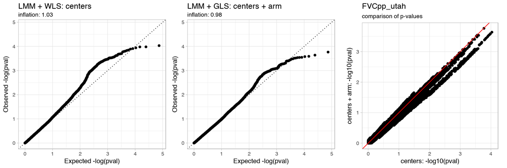

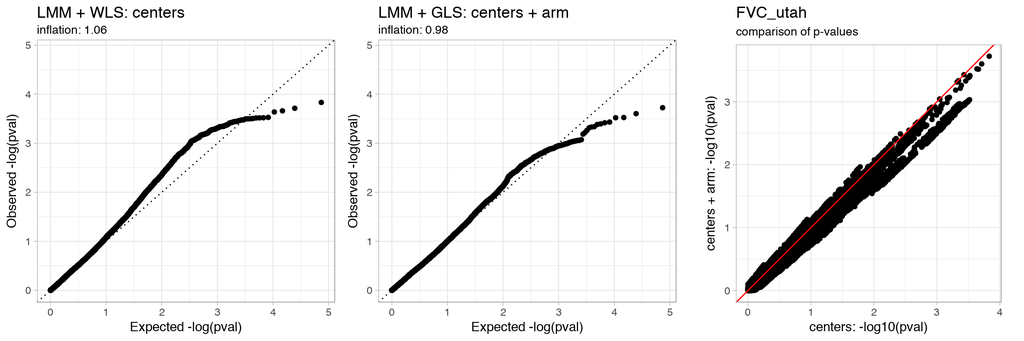

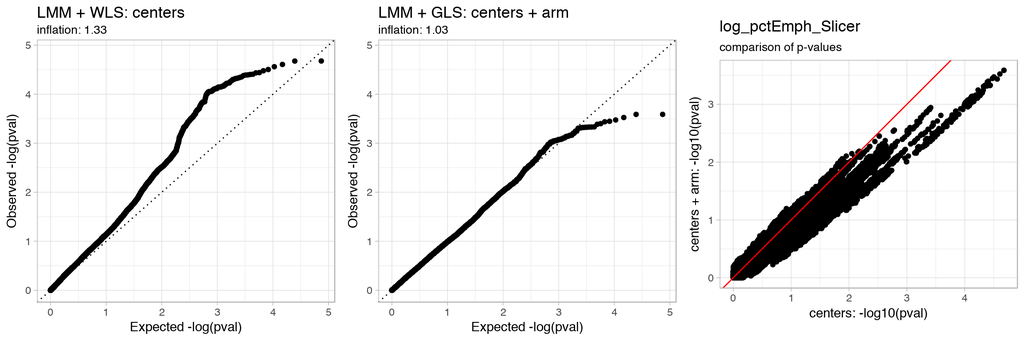

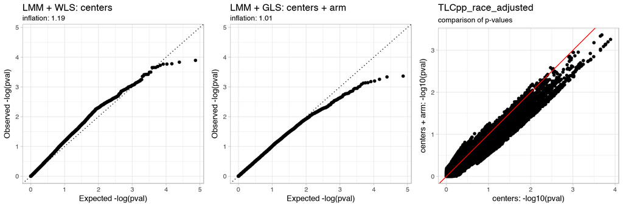

# 4 Interaction scans

We compare two scans:

1. `centers`: we included the only random effect `(1|ccenter)`
2. `centers + arm + arm_d`: we included three random effects `(1|ccenter)`, `(1|sid)` and `(1|esid)`
   - `(1|sid)` has the var-covar matrix equal to ARM (not GARM).
   - `(1|esid)` (`e` stands for environment) has the var-covar matrix equal to ARM * D (element-wise multiplication)
   - D is a relationship matrix due to exposure (SmokCigNow)

Onservations

- The second scan `centers + arm + arm_d` does improves the inflation in comparison to the first scan `centers`, but the inflation is still high.
  - A possible explanation is inaccurate or even completely erroneous estimation of variance components
- The only acceptable inflation for the second scan `centers + arm + arm_d` is shown for low-heritability traits
  - `FVCpp_utah` (`h2_arm` 0, `h2_arm_d` 0.04, lambda 1.06)
  - `FVC_utah` (`h2_arm` 0, `h2_arm_d` 0.03, lambda 1.06)

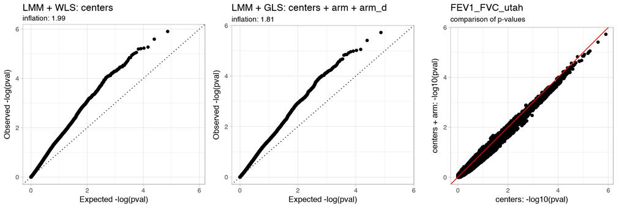

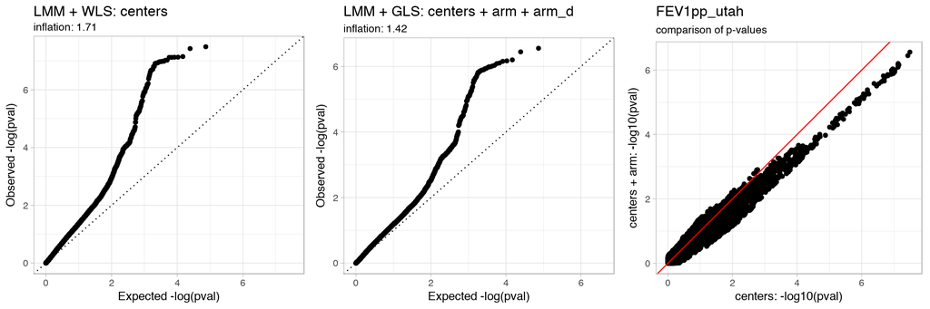

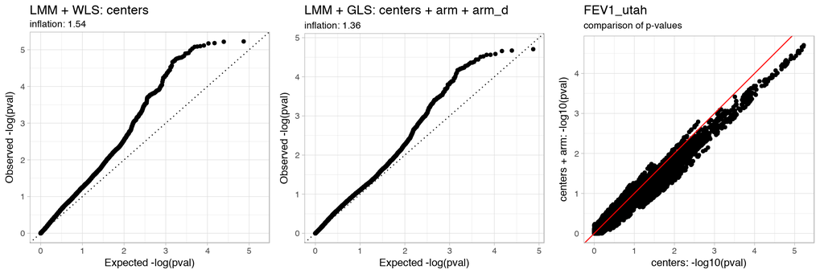

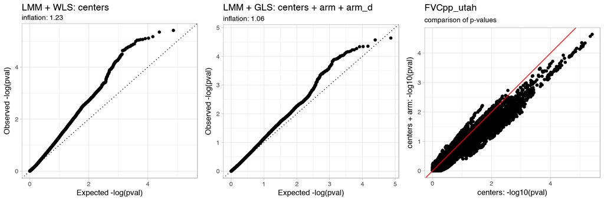

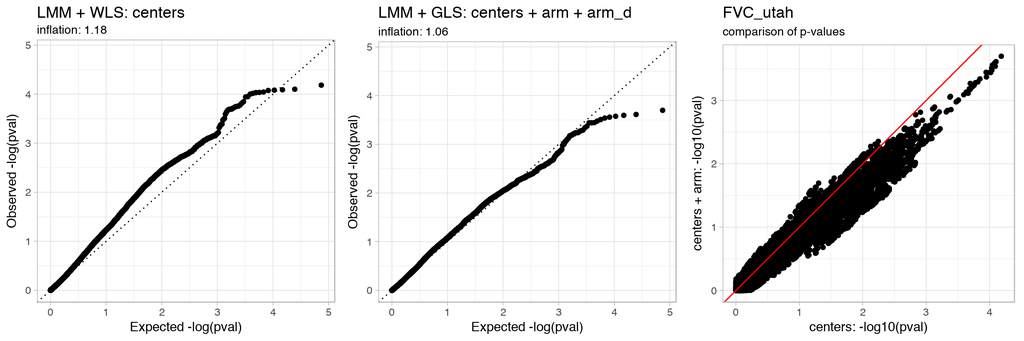

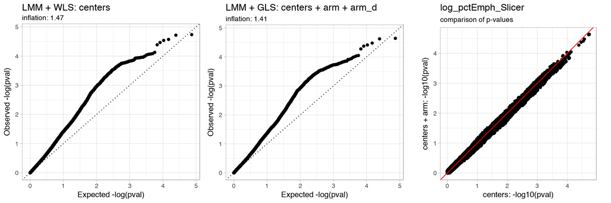

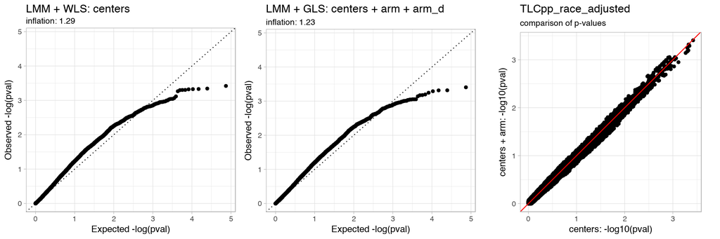

# 5 Conclusion

Possible explanations of inflated statistics in the interaction analysis (LMM + GLS):

- estimated variance components are far from the true ones
- imbalance in exposed and unexposed groups

Things to do:

- run the interaction analysis (LMM + GLS) in a different way
  - `centers + arm` instead of `centers + arm + arm_d`
- run simulations with known variance components
- run simulations with balanced exposed and unexposed groups

```r
table(phen$SmokCigNow)
```

```
   0    1
 657 2643
```

# 6 References